# PREP ANNEX 1 - case studies

….

Luisa M. Mimmi<sup>1</sup>

<sup>1</sup>Economics Advisor at Ministry of Economics & Finance (MEF) - G20

Last updated: 27 May, 2021

# Set up + colors

# UPDATED FILE loading

# `casi` cleaning / manip / flag

https://stackoverflow.com/questions/24173194/remove-parentheses-and-text-within-from-strings-in-r FLAGS from: https://github.com/RobertMyles/flagfillr/tree/master/country-flags/png100px

# SAVE casi

```r
###=== 8)   save FINAL results
save(casi, file = here::here("maintenance_paper", "casi.Rdata"))
```

# TABLE CASES AT A GLANCE

Prepare a Table that shows the BASIC (flag, id name, policy, sector)

```r
case_glance <- casi %>%
  dplyr::select(country, flag, name, policy, sector) %>%
  dplyr::arrange(country) #%>%   filter(country != "FFF (from EU)"  )


class(case_glance)
```

```
## [1] "tbl_df"     "tbl"        "data.frame"
```

```r
# first half
ft_glance1 <- case_glance[1:21 ,]

ft_glance_fl1 <- ft_glance1 %>%  flextable()  %>%
  compose( j = "flag",
                        value = as_paragraph(
                          as_chunk(""),
                          as_image(src = flag, width = 0.3, height = 0.2),
                          as_chunk("")
                        ))  %>%
  autofit() %>%
  bold( bold = TRUE, j = 3, part = "body") %>%
  bold( bold = TRUE,   part = "header") %>%
  color( color = "white",   part = "header") %>%
  bg( bg = bluMEFprinc,   part = "header") %>%
  bg( bg = grigioSfondo, part = "body", source = j) %>%
  border_outer(border = brdr) %>%
  border_inner(border = brdr_in)

ft_glance_fl1
```

country

flag

name

policy

sector

AUS

Roads to Recovery Program

funding

transportation

AUS

Bridges Renewal Program

funding

transportation

BRA

New Basic Sanitation Regulatory Framework

planning; funding; delivery

Water-Waste

BRA

PROSEFER – National Railway Safety Program in Urban Areas

planning

transportation; social

CAN

Canada Core Public Infrastructure Survey

planning

Water-Waste; transportation; social

CAN

Municipal Asset Management Program

delivery

other

CHE

National Roads and Agglomeration Transport Fund

planning; funding; delivery

transportation

CHE

Electricity Grid Usage Tariff

planning; funding; delivery

energy

CHN

Retroftting Ageing Highway Bridges

planning

transportation; social

CHN

Circular of the Ministry of Finance on Issuing the Operation Guideline for Performance Management of PPP Projects

planning; funding; delivery

energy; Water-Waste; transportation; ICT; social; other

EGY (from EIB)

CAIRO METRO REHABILITATION

planning; delivery

transportation

ESP (from EIB)

Metro de Madrid Infrastructure upgrade

planning; delivery

transportation

ETH (from EU)

Road Sector Policy Support Programmes – Ethiopia (Sector Budget Support Modality)

planning; funding; delivery

transportation

FFF (from EU)

[figure not shown]

Sub-Saharan Africa Transport Policy Program - SSATP

planning; funding; delivery

transportation

FRA

Sud Europe Atlantique High Speed Rail Link

planning; funding; delivery

transportation

GBR

AMP7 – Ofwat Price Review 19

funding; delivery

Water-Waste

GBR

Control Period 6 (2019 – 2024) – Asset Information Services Strategic Plan

planning; delivery

transportation; ICT

GER

A) Bridge Modernization Program, Retrofitting of Older Road Bridges  
B) Intelligent Bridge

planning; delivery

transportation

GER

Bundesnetzagentur (BNetzA), the German Federal multisector economic regulator

delivery

energy

IDN

Eastern Sumatera Highway Preservation in Riau Province (Non Toll Road)

planning; funding; delivery

transportation

IDN

Eastern Sumatera Highway Preservation in South Sumatera Province (Non Toll Road)

planning; funding; delivery

transportation

```r
# ft_glance_fl2 <- void(ft_glance_fl, ~  flag)
# print(ft_glance_fl, preview= "docx")
# save in format
save_as_image(x = ft_glance_fl1, path =  here::here("images", "0_ft_glance_fl1.png")) # OK!
```

```
## [1] "/Users/luisamimmi/GoogleDrive/Github/Maintenance/images/0_ft_glance_fl1.png"
```

```r
# second half
N <- nrow(case_glance)

ft_glance2 <- case_glance[22:N,]

ft_glance_fl2 <- ft_glance2 %>%  flextable()  %>%
  compose( j = "flag",
                        value = as_paragraph(
                          as_chunk(""),
                          as_image(src = flag, width = 0.3, height = 0.2),
                          as_chunk("")
                        ))  %>%
  autofit() %>%
  bold( bold = TRUE, j = 3, part = "body") %>%
  bold( bold = TRUE,   part = "header") %>%
  color( color = "white",   part = "header") %>%
  bg( bg = bluMEFprinc,   part = "header") %>%
  bg( bg = grigioSfondo, part = "body", source = j) %>%
  border_outer(border = brdr) %>%
  border_inner(border = brdr_in)

ft_glance_fl2
```

| country | flag | name | policy | sector |
| --- | --- | --- | --- | --- |
| IND |  | Long term O&M of Infrastructure Assets through Public Private Partnerships | planning; funding; delivery | transportation |
| ITA |  | Bridge safety guidelines | planning | transportation |
| ITA |  | ANAS - planned road maintenance | planning; funding; delivery | transportation; ICT |
| JPN |  | National Strategy for Life Extension of Infrastructure | planning; delivery | Water-Waste; transportation; social |
| JPN |  | Fundamental Policy and Guideline for pre-flood emergency reservoir drawdown operational procedure for enhanced flood management | planning; funding; delivery | energy; Water-Waste |
| KOR |  | Master Plans for Managing Infrastructure (2020~2025, announced May 11, 2020), established according to Article 8 of the Framework Act on Sustainable Infrastructure Management | planning; delivery | energy; Water-Waste; transportation; information and communications; other |
| KOR |  | Seoul Metropolitan City’s Sustainable Infrastructure Management Plan | planning; funding; delivery | Water-Waste; transportation; other |
| MEX |  | Mexico Tollroads MRO Model (Maintainer - Rehabilitator – Operator) | planning; funding; delivery | transportation |
| NLD |  | Procurement of innovative circular and modular bridges | planning; funding; delivery | transportation; social; other (sustainability) |
| NLD |  | Vital Assets (Dutch: “Vitale Assets”) | planning; funding; delivery | transportation |
| RUS |  | Rosmor PPP | planning; funding; delivery | energy; transportation |
| RUS |  | Optimization of electricity costs for road lightning of federal, regional (inter-municipal) and local importance roads using energy performance contracts | planning; funding; delivery | energy; transportation |
| SAU |  | Treated Wastewater Use Scheme in Al Hasa Oasis | delivery | Water-Waste |
| SAU |  | Improve the efficiency of sea water desalination plants in the Kingdom of Saudi Arabia- Shuaiba 1 Plant | planning; delivery | energy; Water-Waste |
| SGP |  | Singapore Air Traffic Management System Enhancement Project | planning; delivery | transportation; ICT |
| SGP |  | Punggol Digital District | delivery | energy |
| TUR |  | Istanbul seismic risk mitigation and emergency preparedness project (ISMEP) | planning; funding; delivery | ICT; social |
| TUR |  | Eurasia Tunnel: Ventilation Optimization Study | planning; funding; delivery | energy; transportation; other |
| USA |  | Pennsylvania Rapid Bridge Replacement | planning; funding; delivery | transportation |
| USA |  | The Transform 66 Outside the Beltway | funding; delivery | transportation |
| ZAF |  | Expanded Public Works Programme Integrated Grant for Municipalities | planning; funding; delivery | transportation; social |
| ZAF |  | Provincial Roads Maintenance Grant | planning; funding; delivery | transportation |

```r
# ft_glance_fl2 <- void(ft_glance_fl, ~  flag)
# print(ft_glance_fl, preview= "docx")
# save in format
save_as_image(x = ft_glance_fl2, path =  here::here("images", "0_ft_glance_fl2.png")) # OK!
```

```
## [1] "/Users/luisamimmi/GoogleDrive/Github/Maintenance/images/0_ft_glance_fl2.png"
```

## — save it in Word picture

```r
# the whole dataset
ft_glance_flall <- case_glance  %>%  flextable()  %>%
  compose( j = "flag",
                        value = as_paragraph(
                          as_chunk(""),
                          as_image(src = flag, width = 0.3, height = 0.2),
                          as_chunk("")
                        ))  %>%
  autofit() %>%
    line_spacing( space = 1, part = "body") %>%
  bold( bold = TRUE, j = "name", part = "body") %>%
  bold( bold = TRUE,   part = "header") %>%
  color( color = "white",   part = "header") %>%
  bg( bg = bluMEFprinc,   part = "header") %>%
  bg( bg = grigioSfondo, part = "body", source = j) %>%
  border_outer(border = brdr) %>%
  border_inner(border = brdr_in)


# function to fit in page
  FitFlextableToPage <- function(ft, pgwidth = 7){
        ft_out <- ft %>% autofit()
        ft_out <- width(ft_out, width = dim(ft_out)$widths*pgwidth /(flextable_dim(ft_out)$widths))
        return(ft_out)
  }

#change to prepare
ft_glance_flw <- FitFlextableToPage(ft_glance_flall)


# save in format
save_as_docx(x = ft_glance_flw, path =  here::here("images", "0_ft_glance_fl_all.docx"))
```

## Key agency/agencies in charge of the intervention

```r
stake <- casi %>%
  dplyr::select(id, name, key_stakes,key_stakes_types)

names(casi)
```

```
##  [1] "checked"
##  [2] "Notes"
##  [3] "Needs_clarifications"
##  [4] "id"
##  [5] "country"
##  [6] "name"
##  [7] "in_annex"
##  [8] "sector"
##  [9] "sub_sectors"
## [10] "admin"
## [11] "key_stakes"
## [12] "key_stakes_types"
## [13] "policy"
## [14] "sub_policy"
## [15] "launched"
```

[output cut: 19 more lines]

```r
stake  %>% count(key_stakes)
```

```
## # A tibble: 40 x 2
##    key_stakes                                                             n
##    <chr>                                                              <int>
##  1 "1) CIAS (Centro Internazionale di Aggiornamento Sperimentale-Sci…     1
##  2 "Anas S.p.A. (Italian government-owned company deputed to the con…     1
##  3 "Brazilian National Treasury"                                          1
##  4 "Bundesnetzagentur (Federal Network Agency for Electricity, Gas, …     1
##  5 "Civil Aviation Authority of Singapore"                                1
##  6 "Department for Transport; Network rail"                               1
##  7 "Department of Infrastructure, Transport, Regional Development an…     2
##  8 "Department of Public Works and Infrastructure"                        1
##  9 "Directorate General of Highways, Ministry of Public Work"             2
## 10 "Ethiopian Roads Authority (ERA), Ethiopian Road Fund Office"          1
## # … with 30 more rows
```

```r
casi$key_stakes_types
```

```
##  [1] "ministry of development; local government agency; regulator (subnational); other government agencies"
##  [2] "private corporation; government agency"
##  [3] "federal fund"
##  [4] "ministry of infrastructure/transportation; other government agency; government-owned corporation"
##  [5] "ministry of development; ministry of energy; local government agency; ministry of transport; other government agencies"
##  [6] "ministry of environment/water; other government agency"
##  [7] "ministry of environment/water; other government agency"
##  [8] "ministry of infrastructure/transportation"
##  [9] "ministry of infrastructure/transportation"
## [10] "ministry of infrastructure/transportation"
## [11] "ministry of finance/tresury"
## [12] "ministry of infrastructure/transportation; other government agency"
## [13] "ministry of infrastructure/transportation; other government agency"
## [14] "authority (roads)"
## [15] "government-owned corporation"
```

[output cut: 28 more lines]

```r
# split
casi %>% group_by(key_stakes_types) %>%
  filter(str_detect(key_stakes_types, "ministry of infrastructure/transportation")) %>%
  summarize(N = n()) -> ministri

casi %>% group_by(key_stakes_types) %>%
  filter(str_detect(key_stakes_types, "regulator")) %>%
  summarize(N = n()) -> regu # 3

casi %>% group_by(key_stakes_types) %>%
  filter(str_detect(key_stakes_types, "authority")) %>%
  summarize(N = n()) -> auto
auto # 6
```

```
## # A tibble: 6 x 2
##   key_stakes_types                                                  N
##   <chr>                                                         <int>
## 1 authority (aviation)                                              1
## 2 authority (roads)                                                 1
## 3 authority (roads); road fund                                      1
## 4 authority (tunnels); other government agency                      1
## 5 ministry of infrastructure/transportation; authority (safety)     1
## 6 private corporation; government agencies; authority (energy)      1
```

```r
casi %>% group_by(key_stakes_types) %>%
  filter(str_detect(string = key_stakes_types, pattern =  "local|city|region|subnational" )) %>%
  summarize(N = n()) -> local
local # 7
```

```
## # A tibble: 6 x 2
##   key_stakes_types                                                        N
##   <chr>                                                               <int>
## 1 city government; ministry of environment/urbanization                   1
## 2 city government; ministry of finance/tresury; ministry of environm…     1
## 3 local government agency                                                 2
## 4 local government agency;  other government agency                       1
## 5 ministry of development; local government agency; regulator (subna…     1
## 6 ministry of development; ministry of energy; local government agen…     1
```

```r
casi %>% group_by(key_stakes_types) %>%
  filter(str_detect(string = key_stakes_types, pattern =  "city" )) %>%
  summarize(N = n()) -> city
city # 2
```

```
## # A tibble: 2 x 2
##   key_stakes_types                                                        N
##   <chr>                                                               <int>
## 1 city government; ministry of environment/urbanization                   1
## 2 city government; ministry of finance/tresury; ministry of environm…     1
```

```r
casi %>% group_by(key_stakes_types) %>%
  filter(str_detect(string = key_stakes_types, pattern =  "local" )) %>%
  summarize(N = n()) -> region
region # 2
```

```
## # A tibble: 4 x 2
##   key_stakes_types                                                        N
##   <chr>                                                               <int>
## 1 local government agency                                                 2
## 2 local government agency;  other government agency                       1
## 3 ministry of development; local government agency; regulator (subna…     1
## 4 ministry of development; ministry of energy; local government agen…     1
```

```r
    printloc <- toString( local[,1],  trim = TRUE  )
    printloc
```

```
## [1] "c(\"city government; ministry of environment/urbanization\", \"city government; ministry of finance/tresury; ministry of environment/urbanization; ministry of disaster/emergency; other city agencies\", \"local government agency\", \"local government agency;  other government agency\", \"mini…
```

```r
casi %>% group_by(key_stakes_types) %>%
  filter(str_detect(string = key_stakes_types, pattern =  "private corporation" )) %>%
  summarize(N = n()) -> private
private #
```

```
## # A tibble: 3 x 2
##   key_stakes_types                                                        N
##   <chr>                                                               <int>
## 1 ministry of infrastructure/transportation; private corporation; th…     1
## 2 private corporation; government agencies; authority (energy)            1
## 3 private corporation; government agency                                  1
```

```r
casi %>% group_by(key_stakes_types) %>%
  filter(str_detect(string = key_stakes_types, pattern =  "government-owned corporation" )) %>%
  summarize(N = n()) -> govown
govown #
```

```
## # A tibble: 3 x 2
##   key_stakes_types                                                        N
##   <chr>                                                               <int>
## 1 government-owned corporation                                            2
## 2 ministry of infrastructure/transportation; government-owned corpor…     1
## 3 ministry of infrastructure/transportation; other government agency…     1
```

```r
 casi %>% group_by(key_stakes_types) %>%
  filter(str_detect(key_stakes_types, ";")) %>%
  summarize(N = n()) -> more

stake_type <- stake  %>% group_by(key_stakes_types ) %>%
  summarise (N = n()) %>%
   mutate(Percent = paste0(round(N/sum(N)*100,1),"%")) %>%
  # adorn percentages
  # mutate(across( c("Percent"), ~ percent_format(accuracy = 0.1, scale = 1)(.))) %>%
  # mutate(across(everything(), ~replace_na(., "…"))) %>%
  # non capisce che sono n
  arrange(desc(N), key_stakes_types)  %>%
  # adorn_percentages(  denominator = 'row', na.rm = TRUE) %>%
  flextable() %>%
   flextable::set_header_labels(key_stakes_types = "Type of agencies involved", N = "N. of cases") %>%
 #  fontsize( i = NULL, j = NULL, size = 11, part = "body") %>%
  bold( bold = TRUE,   part = "header") %>%
  color( color = "white",   part = "header") %>%
  bg( bg = bluMEFprinc,   part = "header") %>%
  bg( bg = grigioSfondo, part = "body", source = j) %>%
  border_outer(border = brdr) %>%
  border_inner(border = brdr_in) %>%
  bg(bg = bordeaux_light, i = ~  key_stakes_types %in% c("government-owned corporation", "ministry of infrastructure/transportation; government-owned corporation"), part = "body") %>%
  bg(bg = verde_light, i = ~  key_stakes_types %in% c("regulator (multi sector)", "regulator (water sector)", "ministry of development; local government agency; regulator (subnational); other government agencies"), part = "body") %>%
  bg(bg = marrone_light, i = ~  key_stakes_types %in%  c ("city government; ministry of environment/urbanization", "city government; ministry of finance/tresury; ministry of environment/urbanization; ministry of disaster/emergency; other city agencies", "local government agency", "local government agency;  other government agency", "ministry of development; local government agency; regulator (subnational); other government agencies", "ministry of development; ministry of energy; local government agency; ministry of transport; other government agencies"), part = "body") %>%
 bg(bg =gialloMEFlight, i = ~  key_stakes_types %in%  c ( "private corporation; government agencies; authority (energy)", "private corporation; government agency", "ministry of infrastructure/transportation; private corporation; think tank"), part = "body") %>%
   fontsize(  size = 14, part = "header") %>%
  fontsize(  size = 12, part = "body") %>%
  autofit()

stake_type
```

| Type of agencies involved | N. of cases | Percent |
| --- | --- | --- |
| ministry of infrastructure/transportation | 6 | 14% |
| ministry of infrastructure/transportation; other government agency | 5 | 11.6% |
| government-owned corporation | 2 | 4.7% |
| local government agency | 2 | 4.7% |
| ministry of environment/water; other government agency | 2 | 4.7% |
| ministry of public works | 2 | 4.7% |
| state department transportation | 2 | 4.7% |
| authority (aviation) | 1 | 2.3% |
| authority (roads) | 1 | 2.3% |
| authority (roads); road fund | 1 | 2.3% |
| authority (tunnels); other government agency | 1 | 2.3% |
| city government; ministry of environment/urbanization | 1 | 2.3% |
| city government; ministry of finance/tresury; ministry of environment/urbanization; ministry of disaster/emergency; other city agencies | 1 | 2.3% |
| federal fund | 1 | 2.3% |
| local government agency; other government agency | 1 | 2.3% |
| ministry of development; local government agency; regulator (subnational); other government agencies | 1 | 2.3% |
| ministry of development; ministry of energy; local government agency; ministry of transport; other government agencies | 1 | 2.3% |
| ministry of finance/tresury | 1 | 2.3% |
| ministry of infrastructure/transportation; authority (safety) | 1 | 2.3% |
| ministry of infrastructure/transportation; government-owned corporation | 1 | 2.3% |
| ministry of infrastructure/transportation; other government agency; government-owned corporation | 1 | 2.3% |
| ministry of infrastructure/transportation; other ministries/agencies | 1 | 2.3% |
| ministry of infrastructure/transportation; private corporation; think tank | 1 | 2.3% |
| ministry of infrastructure/transportation; provincial departments of transport | 1 | 2.3% |
| private corporation; government agencies; authority (energy) | 1 | 2.3% |
| private corporation; government agency | 1 | 2.3% |
| regulator (multi sector) | 1 | 2.3% |
| regulator (water sector) | 1 | 2.3% |
| various international partners | 1 | 2.3% |

```r
# save in format
save_as_image(x = stake_type, path =  here::here("images", "1_stake_type.png")) # OK!
```

```
## [1] "/Users/luisamimmi/GoogleDrive/Github/Maintenance/images/1_stake_type.png"
```

## Key agencies [simplified ]

```r
# (tolgo le percentuali che confondono)
simpli_agents <- tribble(
    ~`Type of agencies most frequently involved`, ~`N. of cases`, # ~`Percent of cases`,
  "ministry of infrastructure/transportation", sum(ministri$N), # NA,
  "regulatory entity", sum(regu$N),  # NA,
  "authority entity", sum(auto$N) , # NA ,
  "region/province/city government", sum(local$N)  , # NA ,
    # "other local government agency",  ,  ,
  "government-owned corporation",  sum(govown$N)  , # NA ,
  "private corporation",  sum(private$N)  , # NA ,
  "more than 1 agency involved", sum(more$N)    # NA
)  %>%
# mutate(`Percent of cases` = paste0(round(`N. of cases`/sum(`N. of cases`)*100,0),"%")) %>%
  arrange(desc(`N. of cases`))

simpli_agents_ft <- simpli_agents %>%
  # adorn_percentages(  denominator = 'row', na.rm = TRUE) %>%
  flextable() %>%
    flextable::set_header_labels(key_stakes_types = "Type of agencies most frequently involved", N = "N. of cases") %>%
  bold( bold = TRUE,   part = "header") %>%
  color( color = "white",   part = "header") %>%
  bg( bg = bluMEFprinc,   part = "header") %>%
  bg( bg = grigioSfondo, part = "body", source = j) %>%
  fontsize( i = NULL, j = NULL, size = 11, part = "body") %>%
  border_outer(border = brdr) %>%
  border_inner(border = brdr_in) %>%
 bg(bg =bordeaux_light, i = ~  `Type of agencies most frequently involved` %in%  c ( "more than 1 agency involved" ), part = "body") %>%
  fontsize(size = 14, part = "header") %>%
  fontsize(size = 12, part = "body") %>%
  autofit()

simpli_agents_ft
```

| Type of agencies most frequently involved | N. of cases |
| --- | --- |
| more than 1 agency involved | 22 |
| ministry of infrastructure/transportation | 17 |
| region/province/city government | 7 |
| authority entity | 6 |
| government-owned corporation | 4 |
| regulatory entity | 3 |
| private corporation | 3 |

```r
# save in format
save_as_image(x = simpli_agents_ft, path =  here::here("images", "1b_stake_type.png")) # OK!
```

```
## [1] "/Users/luisamimmi/GoogleDrive/Github/Maintenance/images/1b_stake_type.png"
```

## The administrative level of interventions

```r
admin <- casi %>%
  dplyr::select(id, name, admin, admin_type)

#names(casi)
admin  %>% count(admin)
```

```
## # A tibble: 19 x 2
##    admin                                     n
##    <chr>                                 <int>
##  1 city                                      3
##  2 federal                                   4
##  3 federal; national                         3
##  4 federal; region                           1
##  5 federal; region; city                     1
##  6 national                                 14
##  7 national; city                            1
##  8 national; city; other                     1
##  9 national; region                          3
## 10 national; region; city                    2
## 11 national; state; region                   1
## 12 national; state; region; city             1
## 13 region                                    2
## 14 region; city                              1
## 15 state                                     1
## 16 state;  region                            1
## 17 state; region; city                       1
## 18 supranational; national                   1
## 19 supranational; national; region; city     1
```

```r
admin  %>% count(admin_type)
```

```
## # A tibble: 17 x 2
##    admin_type                                n
##    <fct>                                 <int>
##  1 supranational; national                   1
##  2 supranational; national; region; city     1
##  3 federal/national                         21
##  4 national; state; region; city             1
##  5 national; region; city                    2
##  6 national; city; other                     1
##  7 national; region                          3
##  8 region                                    2
##  9 city                                      3
## 10 federal; region                           1
## 11 federal; region; city                     1
## 12 state;  region                            1
## 13 region; city                              1
## 14 state                                     1
## 15 national; city                            1
## 16 state; region; city                       1
## 17 national; state; region                   1
```

```r
admin_type <- admin  %>%
  dplyr::group_by(admin_type ) %>%
  dplyr::summarise (N = n()) %>%
  #, Percent
  dplyr::mutate(Percent = paste0(round(N/sum(N)*100,1),"%")) %>%
  dplyr::arrange( desc(N),
                  admin_type )  %>%
  # adorn_percentages(  denominator = 'row', na.rm = TRUE) %>%
  flextable() %>%
  set_header_labels(admin_type = "Administrative level", N = "N. of cases") %>%
  bold( bold = TRUE,   part = "header") %>%
  color( color = "white",   part = "header") %>%
  bg( bg = bluMEFprinc,   part = "header") %>%
  bg( bg = grigioSfondo, part = "body", source = j) %>%
  bg(bg = bordeaux_light, i = ~  admin_type %in% "federal/national", part = "body") %>%
  bg(bg = verde_light, i = ~  admin_type %in% c("region", "city", "region; city"), part = "body") %>%

  border_outer(border = brdr) %>%
  border_inner(border = brdr_in)%>%
  fontsize(  size = 14, part = "header") %>%
  fontsize(  size = 12, part = "body") %>%
  autofit()

admin_type
```

| Administrative level | N. of cases | Percent |
| --- | --- | --- |
| federal/national | 21 | 48.8% |
| national; region | 3 | 7% |
| city | 3 | 7% |
| national; region; city | 2 | 4.7% |
| region | 2 | 4.7% |
| supranational; national | 1 | 2.3% |
| supranational; national; region; city | 1 | 2.3% |
| national; state; region; city | 1 | 2.3% |
| national; city; other | 1 | 2.3% |
| federal; region | 1 | 2.3% |
| federal; region; city | 1 | 2.3% |
| state; region | 1 | 2.3% |
| region; city | 1 | 2.3% |
| state | 1 | 2.3% |
| national; city | 1 | 2.3% |
| state; region; city | 1 | 2.3% |
| national; state; region | 1 | 2.3% |

```r
# save in format
save_as_image(x = admin_type, path =  here::here("images", "2_admin_type.png")) # OK!
```

```
## [1] "/Users/luisamimmi/GoogleDrive/Github/Maintenance/images/2_admin_type.png"
```

## Status and recent launch for most cases

> Problem x axis !!!!!!!!!!1

• Over 50% of cases launched in the last decade

```r
casi_year <- casi  %>%
  select(id, launched, year_laun) %>%
  group_by( year_laun) %>%
  summarise( N = n())   %>%
  dplyr::mutate (decade = case_when(
    year_laun < 2000 ~ "1990s",
    year_laun >= 2000 & year_laun < 2010    ~ "2000s",
    year_laun >= 2010 & year_laun < 2020    ~ "2010s",
     year_laun >= 2020   ~ "2020s"
  ))

class(casi_year$year_laun)
```

```
## [1] "integer"
```

```r
#Turn your 'treatment' column into a character vector
#casi_year$year_laun <- as.character(casi_year$year_laun)
table(casi_year$year_laun,casi_year$N )
```

```
##
##        1 2 3 5 6 14
##   1990 1 0 0 0 0  0
##   2001 1 0 0 0 0  0
##   2006 0 1 0 0 0  0
##   2011 0 1 0 0 0  0
##   2013 1 0 0 0 0  0
##   2014 1 0 0 0 0  0
##   2016 0 0 1 0 0  0
##   2017 0 0 0 1 0  0
##   2019 0 0 0 0 1  0
##   2020 0 0 0 1 0  0
##   2021 0 1 0 0 0  0
```

```r
#Then turn it back into a factor with the levels in the correct order
casi_year$year_laun <-  factor(casi_year$year_laun)
table(casi_year$year_laun, useNA = "always")
```

```
##
## 1990 2001 2006 2011 2013 2014 2016 2017 2019 2020 2021 <NA>
##    1    1    1    1    1    1    1    1    1    1    1    1
```

```r
levels(casi_year$year_laun) # [1] "1990" "2001" "2006" "2011" "2013" "2016" "2017" "2019" "2020" "2021"
```

```
##  [1] "1990" "2001" "2006" "2011" "2013" "2014" "2016" "2017" "2019" "2020"
## [11] "2021"
```

```r
casi_year$year_laun <-  fct_explicit_na(casi_year$year_laun, na_level = "Missing yyy")

casi_year <- casi_year %>%
  mutate(year_laun = fct_relevel(year_laun, "1990", "2001", "2006", "2011", "2013", "2016", "2017", "2019", "2020", "2021", "Missing yyy"))
levels(casi_year$year_laun)
```

```
##  [1] "1990"        "2001"        "2006"        "2011"        "2013"
##  [6] "2016"        "2017"        "2019"        "2020"        "2021"
## [11] "Missing yyy" "2014"
```

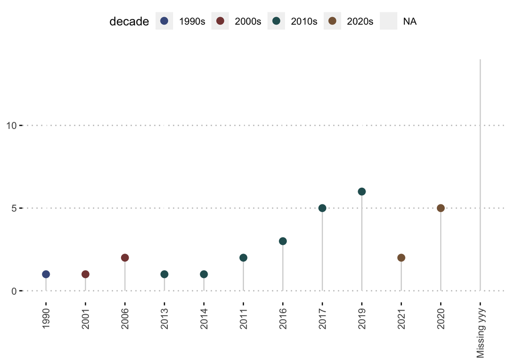

```r
# plot
yeardot <- ggpubr::ggdotchart(data =  casi_year,
           x =  "year_laun",
           y = "N"   ,
           group =  "decade" ,
           color = "decade" ,
           palette = palette_g20,
           # sorting = "descending",
           add = "segments",
           ylab = FALSE, # rotated!
           xlab = FALSE,
           #title = "",
           ggtheme = theme_pubclean(),
           dot.size = 3
           )
#+ geom_hline(yintercept = 31, linetype = 2, color = "lightgray")


yeardot
```

```r
 ggsave(yeardot, filename = here::here("images", "3_yeardot.png") )
```

# SECTOR

## - Wrangle sector

## - Diamond chart by sector (individual all counted ) OK!

```r
# plot with no intersection
sect_alone_counts <- c(transportation = sum(as.numeric(casi_sect_split$transportation)),
                WaterWaste = sum(as.numeric(casi_sect_split$water_waste)),
                energy = sum(as.numeric(casi_sect_split$energy)),
                social =    sum(as.numeric(casi_sect_split$social)),
                ICT = sum(as.numeric(casi_sect_split$ICT)),
                other = sum(as.numeric(casi_sect_split$other))
)

# AS df + transpose
sect_alone_counts_df <- as.data.frame(t(as.matrix(sect_alone_counts)))
 sect_alone_counts_df
```

```
##   transportation WaterWaste energy social ICT other
## 1             33         10     10      8   5     6
```

```r
 class(sect_alone_counts_df)
```

```
## [1] "data.frame"
```

```r
# sect chart prep
sect_alone_prep <- rbind(  rep(33,6),
                           rep(0,6),
                           sect_alone_counts_df
                           )
sect_alone_prep
```

```
##   transportation WaterWaste energy social ICT other
## 1             33         33     33     33  33    33
## 2              0          0      0      0   0     0
## 3             33         10     10      8   5     6
```

```r
rownames(sect_alone_prep) <- c( "max", "min",  "single sector")
sect_alone_prep
```

```
##               transportation WaterWaste energy social ICT other
## max                       33         33     33     33  33    33
## min                        0          0      0      0   0     0
## single sector             33         10     10      8   5     6
```

```r
# Color vector rgb(red, green, blue, alpha)
colors_border = bordeaux
colors_in = bordeaux_light # piu transp

vlabels = rownames(sect_alone_prep[-c(1,2),])

# Custom the radarChart !
par(mar=c(0,0,0,0))

# fmsb::radarchart(sect_alone_prep)

radarsect <- fmsb::radarchart(sect_alone_prep,
                             axistype = 1,
                             #custom polygon
                              pcol= colors_border , # color polygon rgb(red, green, blue, alpha)
                              pfcol= colors_in, # (0,0.2,.8,0.3), # color polygon filling (last is transparency)
                             plwd=4 ,
                             #custom the grid
                             cglcol="grey", cglty=1, axislabcol="grey",
                             #caxislabels=seq(from = 0,to = 52,by = 5),
                             caxislabels= c(0,8,16,25,33),
                             cglwd=0.8,
                             maxmin = TRUE ,
                             #custom labels
                             vlcex=0.9
                             #, title="Distribution by sector \n (not countingmultiple sectors)"
)
radarsect
```

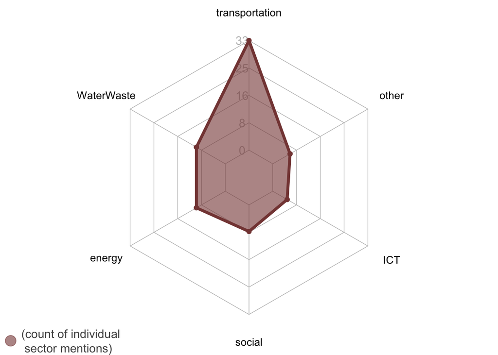

```r
## Add a legend
legend("bottomleft",
       yjust = 1,
       legend = c("(count of individual \n sector mentions)"),
       bty = "n",
       pch=20 ,
       col=colors_in ,
       text.col = "#000000BF", #"grey",
       cex=1,
       pt.cex=3)
```

### — save png

```r
# SAVE image set
png (filename = here::here("images", "5_radar_sect_ind_plot.png")#,
     # width = 601, height = 488# ,units = "cm"
     )

#image create
  radar_sect_ind <- fmsb::radarchart(sect_alone_prep,
                             axistype = 1,
                             #custom polygon
                              pcol= colors_border , # color polygon rgb(red, green, blue, alpha)
                              pfcol= colors_in, # (0,0.2,.8,0.3), # color polygon filling (last is transparency)
                             plwd=4 ,
                             #custom the grid
                             cglcol="grey", cglty=1, axislabcol="grey",
                             #caxislabels=seq(from = 0,to = 52,by = 5),
                             caxislabels= c(0,8,16,25,33),
                             cglwd=0.8,
                             maxmin = TRUE ,
                             #custom labels
                             vlcex=0.9
                             #, title="Distribution by sector \n (not countingmultiple sectors)"
)
radar_sect_ind
```

```r
## Add a legend
legend("bottomleft",
       yjust = 1,
       legend = c("(count of individual \n sector mentions)"),
       bty = "n",
       pch=20 ,
       col=bordeaux_light,
       text.col = "#000000BF", #"grey",
       cex=1,
       pt.cex=3)
# SAVE image UN set
dev.off()
```

```r
# ALL POSSIBLE (single + COMBINATIONs)
sect_sums <- c( casi_sector_count[1,2],
casi_sector_count[2,2],
casi_sector_count[3,2],
casi_sector_count[4,2],
casi_sector_count[5,2],
casi_sector_count[6,2],
casi_sector_count[7,2],
casi_sector_count[8,2],
casi_sector_count[9,2],
casi_sector_count[10,2],
casi_sector_count[11,2],
casi_sector_count[12,2],
casi_sector_count[13,2],
casi_sector_count[14,2],
casi_sector_count[15,2]#,
# casi_sector_count[16,2],
# casi_sector_count[17,2],
# casi_sector_count[18,2]
  )


# opzione 2
sect_sums_df <- as.data.frame(sect_sums)
sect_sums_df[1]
```

```
##    n
## 1 18
```

```r
 names(sect_sums_df)[1] <-   toString( casi_sector_count[1,1])    # "transport"
 names(sect_sums_df)[2] <- toString( casi_sector_count[2,1])
 names(sect_sums_df)[3] <- toString( casi_sector_count[3,1])

 names(sect_sums_df)[4] <- toString( casi_sector_count[4,1])
 names(sect_sums_df)[5] <- toString( casi_sector_count[5,1])
 names(sect_sums_df)[6] <- toString( casi_sector_count[6,1])
 names(sect_sums_df)[7] <- toString( casi_sector_count[7,1])
 names(sect_sums_df)[8] <- toString( casi_sector_count[8,1])
 names(sect_sums_df)[9] <- toString( casi_sector_count[9,1])
 names(sect_sums_df)[10] <- toString( casi_sector_count[10,1])
 names(sect_sums_df)[11] <- toString( casi_sector_count[11,1])
 names(sect_sums_df)[12] <- toString( casi_sector_count[12,1])
 names(sect_sums_df)[13] <- toString( casi_sector_count[13,1])
 names(sect_sums_df)[14] <- toString( casi_sector_count[14,1])
 names(sect_sums_df)[15] <- toString( casi_sector_count[15,1])
 # names(sect_sums_df)[16] <-toString( casi_sector_count[16,1])
 # names(sect_sums_df)[17] <- toString( casi_sector_count[17,1])
 # names(sect_sums_df)[18] <- toString( casi_sector_count[18,1])
```

## - sect prep 4 Diamond

```r
 max(casi_sector_count$n)
```

```
## [1] 18
```

```r
# To use the fmsb package, I have to add 2 lines to the dataframe: the max and min of each topic to show on the plot!
sect_prep <- rbind(rep(18, 15 ), #min(casi_pol_count$n)) ,
                  rep(0,15) , # min  bound
                  sect_sums_df, # multiple policy area
                  sect_alone_trans
                                    ) # only single policy area
sect_prep
```

```
##                    transportation energy transportation; ICT
## 1                              18     18                  18
## 2                               0      0                   0
## 3                              18      3                   3
## sect_alone_trans_n             18      3                   3
##                    transportation; social Water-Waste
## 1                                      18          18
## 2                                       0           0
## 3                                       3           3
## sect_alone_trans_n                      3           3
##                    energy; transportation energy; Water-Waste
## 1                                      18                  18
## 2                                       0                   0
## 3                                       2                   2
## sect_alone_trans_n                      2                   2
##                    Water-Waste; transportation; social
## 1                                                   18
## 2                                                    0
## 3                                                    2
## sect_alone_trans_n                                   2
##                    energy; transportation; other
## 1                                             18
## 2                                              0
## 3                                              1
## sect_alone_trans_n                             1
##                    energy; Water-Waste; transportation; ICT; social; other
## 1                                                                       18
## 2                                                                        0
## 3                                                                        1
## sect_alone_trans_n                                                       1
##                    energy; Water-Waste; transportation; information and communications; other
## 1                                                                                          18
## 2                                                                                           0
## 3                                                                                           1
## sect_alone_trans_n                                                                          1
##                    ICT; social other
## 1                           18    18
## 2                            0     0
## 3                            1     1
## sect_alone_trans_n           1     1
##                    transportation; social; other (sustainability)
## 1                                                              18
## 2                                                               0
## 3                                                               1
## sect_alone_trans_n                                              1
##                    Water-Waste; transportation; other
## 1                                                  18
## 2                                                   0
## 3                                                   1
## sect_alone_trans_n                                  1
```

```r
rownames(sect_prep) <- c( "max",
                          "min",
                          "multiple sector",
                          "single sector"
                          )
sect_prep
```

```
##                 transportation energy transportation; ICT
## max                         18     18                  18
## min                          0      0                   0
## multiple sector             18      3                   3
## single sector               18      3                   3
##                 transportation; social Water-Waste energy; transportation
## max                                 18          18                     18
## min                                  0           0                      0
## multiple sector                      3           3                      2
## single sector                        3           3                      2
##                 energy; Water-Waste Water-Waste; transportation; social
## max                              18                                  18
## min                               0                                   0
## multiple sector                   2                                   2
## single sector                     2                                   2
##                 energy; transportation; other
## max                                        18
## min                                         0
## multiple sector                             1
## single sector                               1
##                 energy; Water-Waste; transportation; ICT; social; other
## max                                                                  18
## min                                                                   0
## multiple sector                                                       1
## single sector                                                         1
##                 energy; Water-Waste; transportation; information and communications; other
## max                                                                                     18
## min                                                                                      0
## multiple sector                                                                          1
## single sector                                                                            1
##                 ICT; social other
## max                      18    18
## min                       0     0
## multiple sector           1     1
## single sector             1     1
##                 transportation; social; other (sustainability)
## max                                                         18
## min                                                          0
## multiple sector                                              1
## single sector                                                1
##                 Water-Waste; transportation; other
## max                                             18
## min                                              0
## multiple sector                                  1
## single sector                                    1
```

## - (NOPE !) Diamond chart by sector (actual combo + individual)

TOP scorer: transportation, `sum(as.numeric(casi_sect_split$transportation))`why? more apparent than other sectors? LEAST scorer ICT `sum(as.numeric(casi_sect_split$ICT))` why? more used as associated tech device

## - Dot chart (alternative for all sectors)

https://medium.com/swlh/beautiful-charts-with-r-and-ggpubr-c94122d6b7c6

```r
# Option 2
sect_prep <-  casi_sector_count
sect_prep$single_check <- ifelse(str_detect( sect_prep$sector, ";"),0, 1  )
# need for grouping in chart
sect_prep$single_check_discr <- as.factor(sect_prep$single_check)
sect_prep$single_check_discr <- factor(sect_prep$single_check_discr,
                                levels = c(0,1),
                                labels = c("multple sector", "individual sector"))
sect_prep
```

```
## # A tibble: 15 x 4
##    sector                                   n single_check single_check_di…
##    <chr>                                <int>        <dbl> <fct>
##  1 transportation                          18            1 individual sect…
##  2 energy                                   3            1 individual sect…
##  3 transportation; ICT                      3            0 multple sector
##  4 transportation; social                   3            0 multple sector
##  5 Water-Waste                              3            1 individual sect…
##  6 energy; transportation                   2            0 multple sector
##  7 energy; Water-Waste                      2            0 multple sector
##  8 Water-Waste; transportation; social      2            0 multple sector
##  9 energy; transportation; other            1            0 multple sector
## 10 energy; Water-Waste; transportation…     1            0 multple sector
## 11 energy; Water-Waste; transportation…     1            0 multple sector
## 12 ICT; social                              1            0 multple sector
## 13 other                                    1            1 individual sect…
## 14 transportation; social; other (sust…     1            0 multple sector
## 15 Water-Waste; transportation; other       1            0 multple sector
```

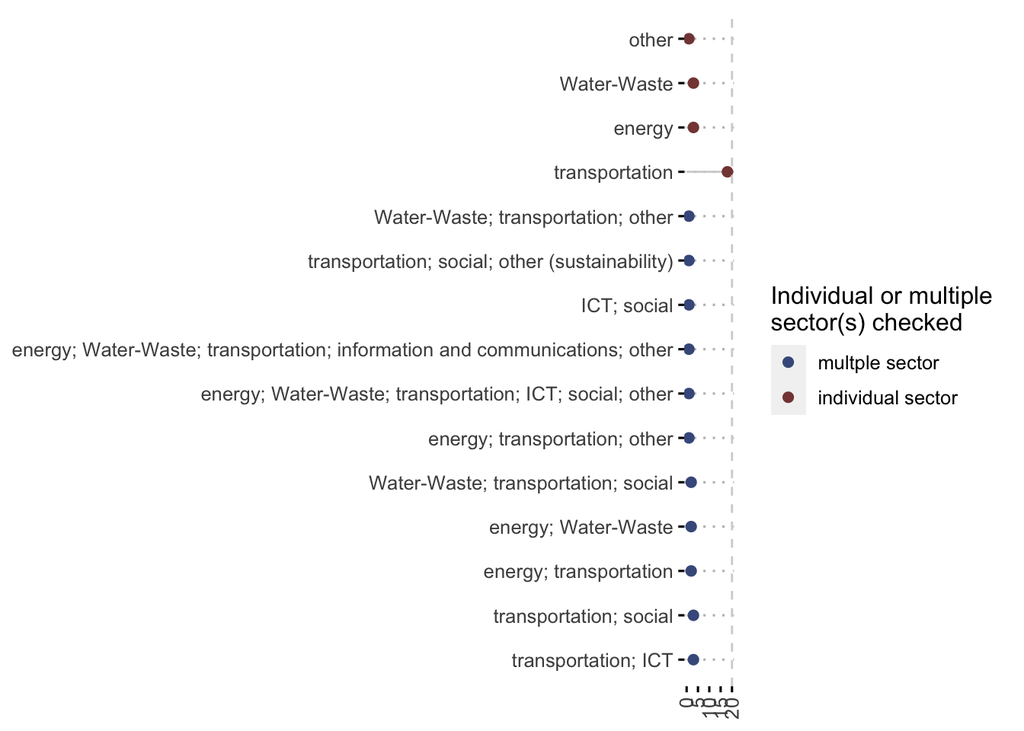

```r
sectordot <- ggdotchart(data =  sect_prep,
           x = "sector",
           y = "n" ,
           group =  "single_check",
           color = "single_check_discr",
           palette = palette_g20,
           sorting = "descending",
           add = "segments",
           ylab = FALSE, # rotated!
           xlab = FALSE,
           #title = "",
           ggtheme = theme_pubclean(),
            dot.size = 2
           ) + geom_hline(yintercept = 20, linetype = 2, color = "lightgray")


# Change the plot orientation: horizontal
sectordot2 <- ggpar(sectordot, legend.title = "Individual or multiple \nsector(s) checked", legend = "right"
                   ,rotate = TRUE
                   )
sectordot2
```

```r
ggsave(sectordot2, filename = here::here("images", "6_sectordot_ACTUAL_plot.png") )
```

# POLICY

## - wrangle policy

## - Diamond chart by policy (actual combo + individual)

```r
# sequential("black", what = "alpha")

max(casi_pol_count$n)
```

```
## [1] 23
```

```r
round(max(casi_pol_count$n)*0.25, 0)
```

```
## [1] 6
```

```r
round(max(casi_pol_count$n)*0.5, 0)
```

```
## [1] 12
```

```r
round(max(casi_pol_count$n)*0.75, 0)
```

```
## [1] 17
```

```r
# To use the fmsb package, I have to add 2 lines to the dataframe: the max and min of each topic to show on the plot!
pol_prep <- rbind(rep(max(casi_pol_count$n)), #min(casi_pol_count$n)) ,
                  rep(0,6) , # min  bound
                  pol_sums_df, # multiple policy area
                  pol_alone_trans) # only single policy area
pol_prep
```

```
##   planning + funding + delivery planning + delivery delivery planning
## 1                            23                  23       23       23
## 2                             0                   0        0        0
## 3                            23                   8        4        4
## 4                            NA                  NA        4        4
##   funding + delivery funding
## 1                 23      23
## 2                  0       0
## 3                  2       2
## 4                 NA       2
```

```r
rownames(pol_prep) <- c( "max", "min", "multiple policy", "single policy")
pol_prep
```

```
##                 planning + funding + delivery planning + delivery delivery
## max                                        23                  23       23
## min                                         0                   0        0
## multiple policy                            23                   8        4
## single policy                              NA                  NA        4
##                 planning funding + delivery funding
## max                   23                 23      23
## min                    0                  0       0
## multiple policy        4                  2       2
## single policy          4                 NA       2
```

```r
# Color vector rgb(red, green, blue, alpha)
# colors_border=c( rgb(0.8, 0.4, 0,0.9),  rgb(0,0.2,.8,0.9) )
# colors_in=c( rgb(1, 0.6, 0, 0.4),       rgb(0,0.2,.8,0.3) )

# Color vector MEF G20
colors_border_b_g =  c( rgb(69/255, 90/255, 139/255,0.9), rgb(189/255, 135/255, 35/255, 1) ) # blue e giallo
colors_in_b_g =  c( rgb(69/255, 90/255, 139/255, 0.4),  rgb(189/255, 135/255, 35/255, 0.4) ) #blu e giallo

 vlabels = rownames(pol_prep[-c(1,2),])


# Custom the radarChart !
par(mar=c(0,0,0,0))

# print plot
radar_policy_mult_ind <-  fmsb::radarchart(pol_prep,
                 axistype=1,
                 #custom polygon
                 pcol= colors_border_b_g, # rgb(0.8, 0.4, 0,0.9) , # color polygon rgb(red, green, blue, alpha)
                 pfcol= colors_in_b_g, # rgb(0.8, 0.4, 0,0.5) , # color polygon filling (last is transparency)
                 plwd=4 ,
                 #custom the grid
                 cglcol="grey", cglty=1, axislabcol="grey",
                 #caxislabels=seq(from = 0,to = 52,by = 5),
                 caxislabels= c(0, 6, 12, 17,23) ,
                 cglwd=0.8,
                 maxmin = TRUE ,
                 #custom labels
                 vlcex=0.9
                  #, title="Distribution by sector \n (not countingmultiple sectors)"
)

radar_policy_mult_ind
```

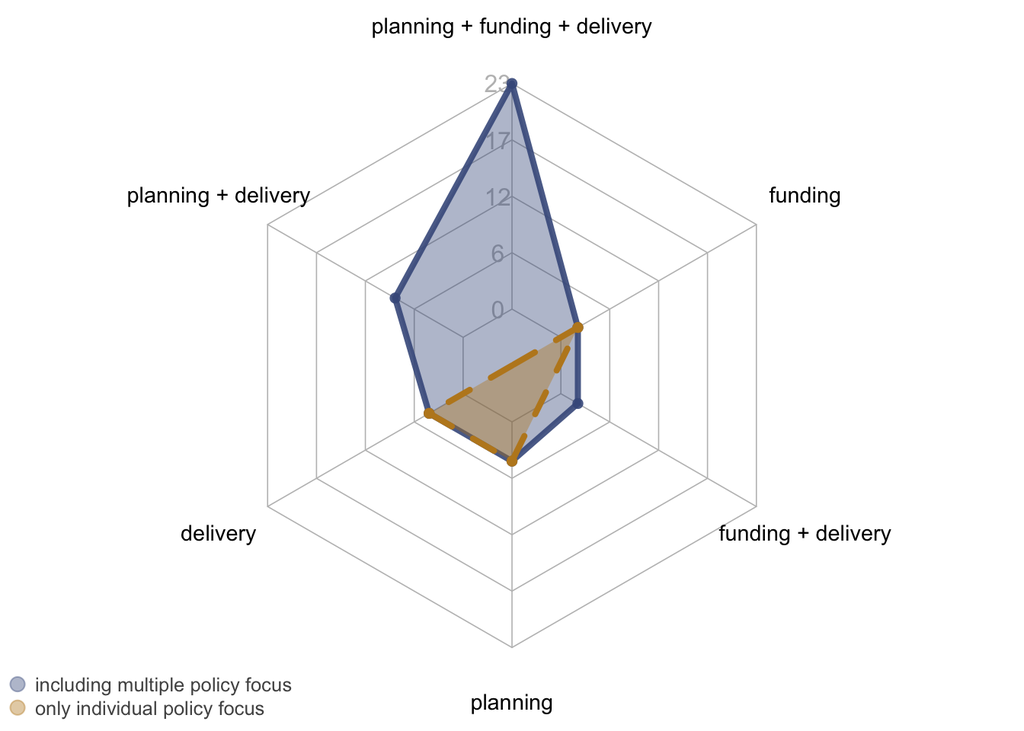

```r
 ## Add a legend
legend("bottomleft",
       legend = c("including multiple policy focus", "only individual policy focus"),
       bty = "n",
       pch=20 ,
       col=colors_in_b_g ,
       text.col = "#000000BF",#"#00000080" ,
       cex=.8,
       pt.cex=2)
```

### — save png

```r
# Color vector MEF G20
colors_border_b_g =  c( rgb(69/255, 90/255, 139/255,0.9), rgb(189/255, 135/255, 35/255, 1) ) # blue e giallo
colors_in_b_g =  c( rgb(69/255, 90/255, 139/255, 0.4),  rgb(189/255, 135/255, 35/255, 0.4) ) #blu e giallo

# SAVE image set
png (filename = here::here("images", "4_radar_policy_mult+ind_plot.png"),
     width = 601, height = 488# ,units = "cm"
     )

#image create
# print plot
radar_policy_mult_ind <-  fmsb::radarchart(pol_prep,
                 axistype=1,
                 #custom polygon
                 pcol= colors_border_b_g, # rgb(0.8, 0.4, 0,0.9) , # color polygon rgb(red, green, blue, alpha)
                 pfcol= colors_in_b_g, # rgb(0.8, 0.4, 0,0.5) , # color polygon filling (last is transparency)
                 plwd=4 ,
                 #custom the grid
                 cglcol="grey", cglty=1, axislabcol="grey",
                 #caxislabels=seq(from = 0,to = 52,by = 5),
                 caxislabels= c(0, 6, 12, 17,23),
                 cglwd=0.8,
                 maxmin = TRUE ,
                 #custom labels
                 vlcex=0.9
                  #, title="Distribution by sector \n (not countingmultiple sectors)"
)

 ## Add a legend
legend("bottomleft",
       legend = c("including multiple policy focus", "only individual policy focus"),
       bty = "n",
       pch=20 ,
       col=colors_in_b_g ,
       text.col = "#000000BF",#"#00000080" , "grey"
       cex=.9,
       pt.cex=3)
# SAVE image UN set
dev.off()
```

> COMMENT interesting how few there are that are not multi-area !!

# TABLE for loop no flag (long)

https://epirhandbook.com/tables-for-presentation.html https://ardata-fr.github.io/flextable-gallery/gallery/2021-03-26-tennis-players/ https://ardata-fr.github.io/flextable-book/rendering.html#simple-export

```r
# add flags to casi
 flag_path <- fs::path_dir("flags")
flag_path
```

[1] “.”

```r
for (i in 1:nrow(casi)){
  onecase <- casi[i,c("id", # country,
                      "flag", "name",
                      "sector", "sub_sectors",
                      "admin", "key_stakes",    #"key_stakes_types",
                      "policy", "sub_policy_clean",
                      "launched",
                      # "desc_objective"    ,"name" ,
                      "purpose",    "intended_outcomes",    "status",
                      # "has_regulatory_innovation",    "has_plan_guidelines_std",  "has_O&M_costs_reduction",
                      # "has_priv", "has_data_collec",  "has_tech40",   "has_resilience",
                      # "has_knowshar", "has_age",
                      "link")]
  # ft <- flextable(as.data.frame(t(onecase))) %>%
  #   autofit()
  # # set_caption(ft, caption = casi[i,"name"])
  # print(ft) # , preview = "docx")
  #

  onecase %>%
    head() %>%
    t() %>%
    as.data.frame() %>%
    tibble::rownames_to_column() %>%
    flextable %>%
    # i in selecting rows
    # compose(#i = "country",
    #   i = "flag",
    #   value = as_paragraph(" ",
    #                        as_image(src = flag, width = .5, height = 0.33),
    #                        " ")
    # ) %>%
    autofit()  -> ft

  # # compose to modify display value
  # ft2 <- flextable::compose(ft,
  #           i = i,
  #           value = as_paragraph( " ",
  #                                 as_image(src = flag, width = .5, height = 0.33),
  #                                 " "
  #           )
  #   )
  #
  # add flags


  # PRINT?
  flextable_to_rmd(ft)  # --- html output

  # rmarkdown::word_document() # ---- WORD OUTPUT
  # print (ft, preview = "docx") # ---- WORD OUTPUT 2 (no format )
  # print(x = ft, target = here::here( "image", "example_table_powerpoint.docx")) #---- WORD OUTPUT 3 (no format )
}
```

| rowname | V1 |
| --- | --- |
| id | BRA-1 |
| flag | /Users/luisamimmi/GoogleDrive/Github/Maintenance/flags/br.png |
| name | New Basic Sanitation Regulatory Framework |
| sector | Water-Waste |
| sub_sectors | water supply; drinking water distribution; waste water collection; waste water treatment; solid waste management; other water & waste (drainage and stormwater management); urban infrastructure |
| admin | national; state; region; city |
| key_stakes | Ministry of Regional Development (federal government); National Agency of Water and Basic Sanitation (federal government); Subnational governments (states and municipalities); Subnational regulatory a… |
| policy | planning; funding; delivery |
| sub_policy_clean | Strategic plan addressing infrastructure assets management / maintenance / repairing; Data collection/analysis effort; Definition/adoption of standards; Institutional capacity/ governance; Strengthene… |
| launched | 2020 |
| purpose | The new basic sanitation regulatory framework: • Determines that the National Water Agency (ANA) is vested with defining reference guidelines for basic sanitation regulation (including quality and eff… |
| intended_outcomes | aimed at boosting productivity growth by providing incentives for incumbent firms to adopt innovative technologies, and encouraging the entry of new and innovative firms in the market place, with evid… |
| status | launched in 2020 (law) ? |
| link | https://www.gov.br/pt-br/noticias/transito-e-transportes/2020/07/novo-marco-de-saneamento-e-sancionado-e-garante-avancos-para-o-pais https://www.gov.br/ana/pt-br/assuntos/saneamento-basico/novo-marco-… |

| rowname | V1 |
| --- | --- |
| id | FRA-1 |
| flag | /Users/luisamimmi/GoogleDrive/Github/Maintenance/flags/fr.png |
| name | Sud Europe Atlantique High Speed Rail Link |
| sector | transportation |
| sub_sectors | rail |
| admin | national; region |
| key_stakes | Sud Europe Atlantique High Speed Rail Link (France); LISEA S.A.S |
| policy | planning; funding; delivery |
| sub_policy_clean | Strategic plan addressing infrastructure assets management / maintenance / repairing; Data collection/analysis effort; Definition/adoption of standards; Regulatory innovations; Socio-economic observat… |
| launched | 2017 |
| purpose | The Sud Europe Atlantique High-Speed Line is a 302-km long dual-track railway between Tours and Bordeaux, with 38km of additional links to the main cities in the South-West of France. (€7.7bn of inves… |
| intended_outcomes | The Sud Europe Atlantique HSL carries 20.5 million passengers per year between the South-West regions of France and Paris, and North and East regions of France. HSL SEA offers journey times between Pa… |
| status | The Sud Europe Atlantique HSL has been in service since 2nd July 2017. |
| link | https://www.lisea.fr/ https://www.mesea.fr/ |

| rowname | V1 |
| --- | --- |
| id | MEX-1 |
| flag | /Users/luisamimmi/GoogleDrive/Github/Maintenance/flags/mx.png |
| name | Mexico Tollroads MRO Model (Maintainer - Rehabilitator – Operator) |
| sector | transportation |
| sub_sectors | roads, urban mobility |
| admin | federal; national |
| key_stakes | Fondo Nacional de Infraestructura (FONADIN) |
| policy | planning; funding; delivery |
| sub_policy_clean | Strategic plan addressing infrastructure assets management / maintenance / repairing; Data collection/analysis effort; Definition/adoption of standards; Institutional capacity/ governance; Strengthene… |
| launched | ? |
| purpose | MRO Tollroads Model Main agents: 1. FONADIN (National Infrastructure Fund. Public trust in charge of coordinating investment in infrastructure mainly in the areas of communications, transportation, hy… |
| intended_outcomes |  |
| status |  |
| link |  |

| rowname | V1 |
| --- | --- |
| id | RUS-1 |
| flag | /Users/luisamimmi/GoogleDrive/Github/Maintenance/flags/ru.png |
| name | Rosmor PPP |
| sector | energy; transportation |
| sub_sectors | energy storage; ports |
| admin | federal; region |
| key_stakes | Ministry of Transport of the Russian Federation; The Federal Agency for Sea and Inland Water Transport (Rosmorrechflot); Federal State Unitary Enterprise “Rosmorport” |
| policy | planning; funding; delivery |
| sub_policy_clean | Strategic plan addressing infrastructure assets management / maintenance / repairing; Institutional capacity/ governance; Tax expenditures allocated to maintenance or rehabilitation purposes; Innovati… |
| launched |  |
| purpose |  |
| intended_outcomes |  |
| status |  |
| link |  |

| rowname | V1 |
| --- | --- |
| id | RUS-2 |
| flag | /Users/luisamimmi/GoogleDrive/Github/Maintenance/flags/ru.png |
| name | Optimization of electricity costs for road lightning of federal, regional (inter-municipal) and local importance roads using energy performance contracts |
| sector | energy; transportation |
| sub_sectors | energy efficiency; roads |
| admin | federal; region; city |
| key_stakes | Ministry of Economic Development of the Russian Federation; Ministry of Energy of the Russian Federation; Ministry of Transport of the Russian Federation; Other relevant authorities including regional… |
| policy | planning; funding; delivery |
| sub_policy_clean | Strategic plan addressing infrastructure assets management / maintenance / repairing; Other pertaining to FUNDING & FINANCING; Solutions improving maintenance planning / lifecycle asset management str… |
| launched |  |
| purpose |  |
| intended_outcomes |  |
| status |  |
| link |  |

| rowname | V1 |
| --- | --- |
| id | SAU-1 |
| flag | /Users/luisamimmi/GoogleDrive/Github/Maintenance/flags/sa.png |
| name | Treated Wastewater Use Scheme in Al Hasa Oasis |
| sector | Water-Waste |
| sub_sectors | water supply; waste water collection; solid waste management; irrigation and agri-business |
| admin | state; region |
| key_stakes | Ministry of Environment, Water and Agriculture Saudi Irrigation Organization |
| policy | delivery |
| sub_policy_clean | Solutions improving maintenance planning / lifecycle asset management strategy / risk management; Solutions integrating resilience into infrastructure intervention |
| launched | ? |
| purpose | The Saud Irrigation Organization (SIO) is a public governmental institution with a mandate to carry out the management, operation and maintenance of irrigation and drainage in the Kingdom. The SIO hea… |
| intended_outcomes | The SIO introduced the Supervisory Control and Data Collection System (SCADA) to operate the irrigation system automatically to control the scheduling and distribution of treated wastewater to farms t… |
| status |  |
| link | The Saudi Irrigation Organization website : https://www.sio.gov.sa/en |

| rowname | V1 |
| --- | --- |
| id | SAU-2 |
| flag | /Users/luisamimmi/GoogleDrive/Github/Maintenance/flags/sa.png |
| name | Improve the efficiency of sea water desalination plants in the Kingdom of Saudi Arabia- Shuaiba 1 Plant |
| sector | energy; Water-Waste |
| sub_sectors | energy efficiency; water supply; desalination |
| admin | national |
| key_stakes | Ministry of Environment, Water, and Agriculture (MEWA); Saline Water Conversion Corporation (SWCC) |
| policy | planning; delivery |
| sub_policy_clean | Strategic plan addressing infrastructure assets management / maintenance / repairing; Solutions improving maintenance planning / lifecycle asset management strategy / risk management |
| launched |  |
| purpose | The KSA is largest desalinated water producer in the World. Currently desalinated water supplied about 60% of total domestic and industrial water demands in the Kingdom. The Saline Water Conversion Co… |
| intended_outcomes | The project started in 2021 and is expected to be completed in 2023. The project will: • Increase water capacity from 223,000 m3/day to 600,000 m3/day that is about 169% increase in capcity; • Reduce … |
| status | The project started in 2021 and is expected to be completed in 2023. |
| link | Saudi Water Partnership Company website at https://www.swcc.gov.sa |